# R Notebook

# Libraries

```r
library(infer)
```

# Data

```r
hb_names <- read_csv("raw_data/covid_raw_data/health_board_names.csv") %>% clean_names()
```

# Data exploration

## HB Age/sex dataset

### Variables in dataset

```r
hb_agesex %>% names()
```

```
 [1] "week_ending"       "hb"                "hbqf"              "age_group"         "age_group_qf"
 [6] "sex"               "sex_qf"            "admission_type"    "admission_type_qf" "number_admissions"
[11] "average20182019"   "percent_variation"
```

The health board number is not very useful or easy to make connections with, we should change this to the name of the health board

```r
hb_agesex <- hb_agesex %>%
  left_join(hb_names, by = "hb")
```

```r
hb_agesex <- hb_agesex %>%
  mutate(hb_name = if_else(
    is.na(hb_name),
    "All Scotland",
    hb_name
  ))
```

| admission_type |
| --- |
| All |
| Emergency |
| Planned |

We have three different admission types (all, emergency, planned) - should we only be looking at emergency admission types (e.g. acute)?

| hb |
| --- |
| S08000015 |
| S08000016 |
| S08000017 |
| S08000019 |
| S08000020 |
| S08000022 |
| S08000024 |
| S08000025 |
| S08000026 |
| S08000028 |

[output cut: 5 more lines]

| week_ending |
| --- |
| 20200105 |
| 20200112 |
| 20200119 |
| 20200126 |
| 20200202 |
| 20200209 |
| 20200216 |
| 20200223 |
| 20200301 |
| 20200308 |

[output cut: 102 more lines]

```r
hb_agesex <- hb_agesex %>%
  mutate(week_ending = ymd(week_ending))
```

```r
hb_agesex <- hb_agesex %>%
  mutate(month = month(week_ending, label = TRUE),
         year = year(week_ending), .after = week_ending)
```

```r
hb_agesex <- hb_agesex %>%
  mutate(is_winter = if_else(
    month %in% c("Dec", "Jan", "Feb"), TRUE, FALSE
  ), .after = month)
```

### Exploratory analysis

#### Compare mean admissions between Covid times and pre-Covid times

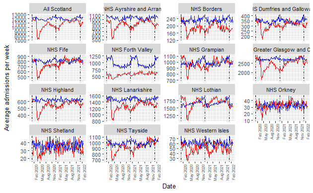

```r
#compare mean admissions in 2020/2021/2022 with 2018/2019 averages
hb_agesex %>%
  filter(admission_type == "Emergency",
         age_group == "All ages",
         sex == "All") %>%
  group_by(hb_name, week_ending) %>%
  summarise(mean_admissions = mean(number_admissions),
            mean_20182019_admissions = mean(average20182019)) %>%
  ggplot() +
    geom_line(aes(x = week_ending,
                  y = mean_admissions), group = 1, colour = "red") +
  geom_line(aes(x = week_ending,
                y = mean_20182019_admissions), group = 1, colour = "blue") +
  scale_x_date(date_breaks = "3 months", date_labels = "%b %Y") +
  theme(axis.text.x = element_text(angle = 90, hjust = 1, size =7)) +
   geom_vline(xintercept = as.numeric(as.Date("2020-01-01")), linetype=4)+
  geom_vline(xintercept = as.numeric(as.Date("2021-01-01")), linetype=4)+
  geom_vline(xintercept = as.numeric(as.Date("2022-01-01")), linetype=4)+
  facet_wrap(~hb_name, scales = "free_y") +
  labs(x = "Date",
       y = "Average admissions per week",
       colour = "Covid vs Pre-Covid")
```

#### Compare number of admissions between winter and non winter

No significant differences

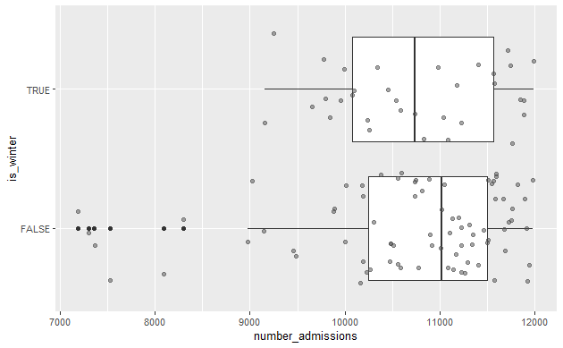

```r
#get boxplots to compare spread of number of admissions for winter vs not winter
hb_agesex %>%
  filter(admission_type == "Emergency",
         age_group == "All ages",
         sex == "All",
         hb_name == "All Scotland") %>%
  ggplot(aes(x = number_admissions,
             y = is_winter)) +
  geom_boxplot() +
  geom_jitter(colour = "grey30", alpha = 0.5)
```

```r
NA
```

Not expecting significant difference

H0 - number of admissions(winter) = number of admissions(not winter) H1 - number of admissions(winter) > number of admissions(not winter)

```r
null_distribution <- hb_agesex %>%
  filter(admission_type == "Emergency",
         age_group == "All ages",
         sex == "All",
         hb_name == "All Scotland") %>%
  specify(number_admissions ~ is_winter) %>%
  hypothesise(null = "independence") %>%
  generate(reps = 5000, type = "permute") %>%
  calculate(stat = "diff in means", order = c("TRUE", "FALSE"))
```

```r
observed_stat <- hb_agesex %>%
  filter(admission_type == "Emergency",
         age_group == "All ages",
         sex == "All",
         hb_name == "All Scotland") %>%
  specify(number_admissions ~ is_winter) %>%
  calculate(stat = "diff in means", order = c("TRUE", "FALSE"))
```

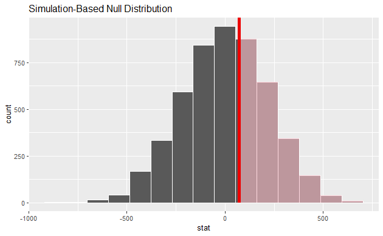

```r
null_distribution %>%
  visualise() +
  shade_p_value(obs_stat = observed_stat, direction = "right")
```

```r
p_value <- null_distribution %>%
  get_p_value(obs_stat = observed_stat, direction = "right")

p_value
```

| p_value |
| --- |
| 0.3862 |

#### Compare mean number of admissions for winter/not winter for different HBs

No significant differences

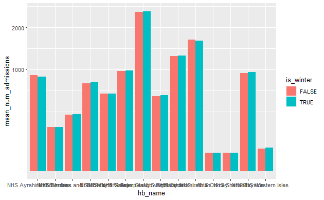

```r
hb_agesex %>%
  filter(admission_type == "Emergency",
         age_group == "All ages",
         sex == "All",
         hb_name != "All Scotland") %>%
  group_by(hb_name, is_winter) %>%
  summarise(mean_num_admissions = mean(number_admissions)) %>%
  ggplot(aes(x = hb_name,
             y = mean_num_admissions,
             fill = is_winter)) +
  geom_col(position = "dodge") +
  scale_y_sqrt()
```

```r
NA
```

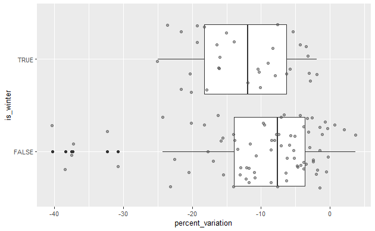

```r
hb_agesex %>%
  filter(admission_type == "Emergency",
         age_group == "All ages",
         sex == "All",
         hb_name == "All Scotland") %>%
  ggplot(aes(x = percent_variation,
             y = is_winter)) +
  geom_boxplot() +
  geom_jitter(colour = "grey30", alpha = 0.5)
```

#### Compare number of admissions by sex and winter/not winter

No significant differences

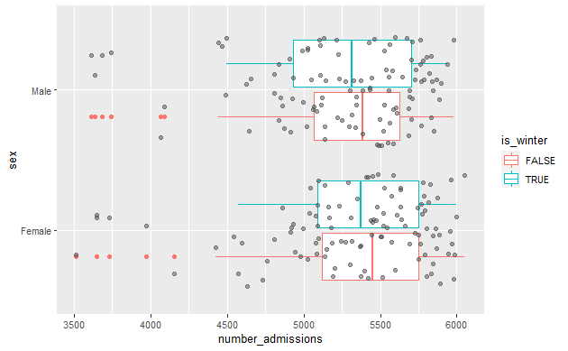

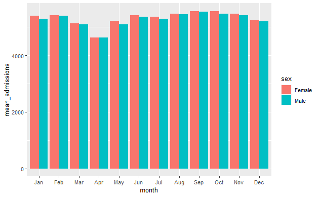

```r
#get bar graphs for mean number of admissions for each month by sex
hb_agesex %>%
  filter(admission_type == "Emergency",
         sex != "All",
         hb_name == "All Scotland") %>%
  group_by(hb_name, month, sex) %>%
  summarise(mean_admissions = mean(number_admissions)) %>%
  ggplot() +
    geom_col(aes(x = month,
                  y = mean_admissions,
                  fill = sex), position = "dodge")
```

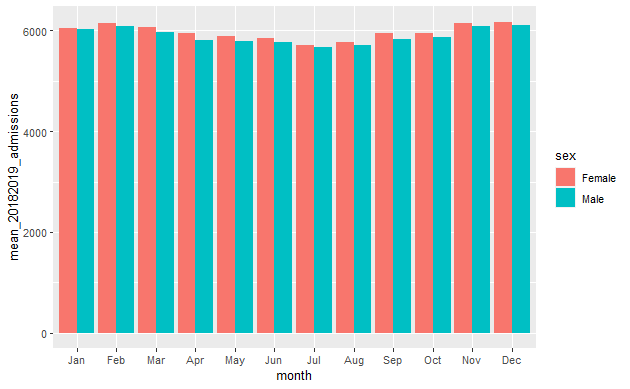

```r
hb_agesex %>%
  filter(admission_type == "Emergency",
         sex != "All",
         hb_name == "All Scotland") %>%
  group_by(hb_name, month, sex) %>%
  summarise(mean_20182019_admissions = mean(average20182019)) %>%
  ggplot() +
  geom_col(aes(x = month,
                  y = mean_20182019_admissions,
                  fill = sex), position = "dodge")
```

#### Compare number of admissions for each age group for winter/not winter

For age groups over 65, admissions are slightly higher in the winter. The same pattern is not seen for younger age groups The increase in admissions in winter months for age groups over 65 was more drastic pre-Covid than during Covid. This is potentially due to the lockdown measures in winter Dec2020/Jan-Feb2021 and some remaining restrictions in winter Dec2021/Jan-Feb 2022 as well as the vaccination campaign targeting these age groups in early 2021 with boosters in late 2021/early 2022.

```r
hb_agesex %>% distinct(age_group)
```

| age_group |
| --- |
| Under 5 |
| 5 - 14 |
| 15 - 44 |
| 45 - 64 |
| 65 - 74 |
| 75 - 84 |
| 85 and over |
| All ages |

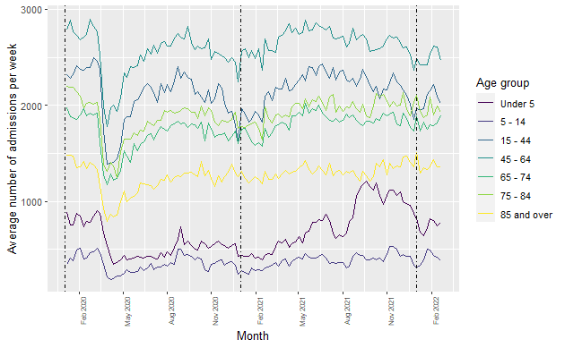

```r
hb_agesex %>%
  filter(admission_type == "Emergency",
         age_group != "All ages",
         hb_name == "All Scotland") %>%
  group_by(hb_name, week_ending, age_group) %>%
  summarise(mean_admissions = mean(number_admissions)) %>%
  ggplot() +
    geom_line(aes(x = week_ending,
                  y = mean_admissions,
                  colour = ordered(age_group, levels = c("Under 5",
                                                       "5 - 14",
                                                       "15 - 44",
                                                       "45 - 64",
                                                       "65 - 74",
                                                       "75 - 84",
                                                       "85 and over")))) +
  scale_x_date(date_breaks = "3 months", date_labels = "%b %Y") +
  theme(axis.text.x = element_text(angle = 90, hjust = 1, size =7)) +
   geom_vline(xintercept = as.numeric(as.Date("2020-01-01")), linetype=4)+
  geom_vline(xintercept = as.numeric(as.Date("2021-01-01")), linetype=4)+
  geom_vline(xintercept = as.numeric(as.Date("2022-01-01")), linetype=4)+
  labs(x = "Month",
       y = "Average number of admissions per week",
       colour = "Age group")
```

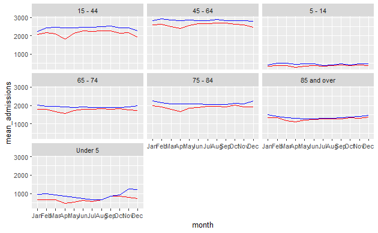

```r
hb_agesex %>%
  filter(admission_type == "Emergency",
         age_group != "All ages",
         hb_name == "All Scotland") %>%
  group_by(hb_name, month, age_group) %>%
  summarise(mean_admissions = mean(number_admissions),
            mean_20182019_admissions = mean(average20182019)) %>%
  ggplot() +
    geom_line(aes(x = month,
                  y = mean_admissions), group = 1, colour = "red") +
    geom_line(aes(x = month,
                  y = mean_20182019_admissions), group = 1, colour = "blue") +
    facet_wrap(~age_group)
```

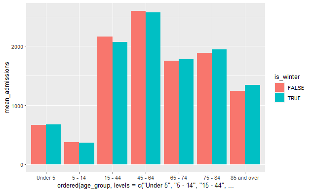

```r
hb_agesex %>%
  filter(admission_type == "Emergency",
         age_group != "All ages",
         hb_name == "All Scotland") %>%
  group_by(hb_name, age_group, is_winter) %>%
  summarise(mean_admissions = mean(number_admissions)) %>%
  ggplot() +
    geom_col(aes(x = ordered(age_group, levels = c("Under 5",
                                                       "5 - 14",
                                                       "15 - 44",
                                                       "45 - 64",
                                                       "65 - 74",
                                                       "75 - 84",
                                                       "85 and over")),
                  y = mean_admissions,
                  fill = is_winter), position = "dodge")
```

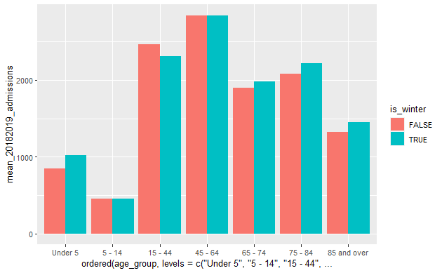

```r
hb_agesex %>%
  filter(admission_type == "Emergency",
         age_group != "All ages",
         hb_name == "All Scotland") %>%
  group_by(hb_name, age_group, is_winter) %>%
  summarise(mean_20182019_admissions = mean(average20182019)) %>%
  ggplot() +
  geom_col(aes(x = ordered(age_group, levels = c("Under 5",
                                                       "5 - 14",
                                                       "15 - 44",
                                                       "45 - 64",
                                                       "65 - 74",
                                                       "75 - 84",
                                                       "85 and over")),
                  y = mean_20182019_admissions,
                  fill = is_winter), position = "dodge")
```

## HB SIMD dataset

### Variables in dataset

```r
hb_simd <- read_csv("raw_data/covid_raw_data/hospital_admissions_hb_simd_20220302.csv") %>% clean_names()
```

```r
hb_simd %>% names(
)
```

```
[1] "week_ending"       "hb"                "hbqf"              "simd_quintile"     "admission_type"
[6] "admission_type_qf" "number_admissions" "average20182019"   "percent_variation"
```

## HB Specialty dataset

### Variables in dataset

```r
hb_specialty <- read_csv("raw_data/covid_raw_data/hospital_admissions_hb_specialty_20220302.csv") %>% clean_names()
```

```r
hb_specialty %>% names()
```

```
 [1] "week_ending"       "hb"                "hbqf"              "admission_type"    "admission_type_qf"
 [6] "specialty"         "specialty_qf"      "number_admissions" "average20182019"   "percent_variation"
```

```r
#join with hb_names to get hb names
hb_specialty <- hb_specialty %>%
  left_join(hb_names, by = "hb")
```

```r
#change week_ending into date format
hb_specialty <- hb_specialty %>%
  mutate(week_ending = ymd(week_ending))
```

```r
hb_specialty <- hb_specialty %>%
  mutate(month = month(week_ending, label = TRUE),
         year = year(week_ending), .after = week_ending)
```

```r
#create winter and non winter groups
hb_specialty <- hb_specialty %>%
  mutate(is_winter = if_else(
    month %in% c("Dec", "Jan", "Feb"), TRUE, FALSE
  ), .after = month)
```

```r
#impute NAs in hb_name with all scotland b/c these are only for the all scotland hb code
hb_specialty <- hb_specialty %>%
  mutate(hb_name = if_else(
    is.na(hb_name),
    "All Scotland",
    hb_name
  ))
```

### Exploratory analysis

```r
hb_specialty %>%
  filter(admission_type == "Emergency",
         specialty != "All",
         hb_name == "All Scotland") %>%
  group_by(hb_name, specialty, is_winter) %>%
  summarise(mean_admissions = mean(number_admissions))
```

| hb_name | specialty | is_winter | mean_admissions |
| --- | --- | --- | --- |
| All Scotland | Accident & Emergency | FALSE | 412.15190 |
| All Scotland | Accident & Emergency | TRUE | 396.60606 |
| All Scotland | Cancer | FALSE | 123.56962 |
| All Scotland | Cancer | TRUE | 129.60606 |
| All Scotland | Cardiology | FALSE | 315.24051 |
| All Scotland | Cardiology | TRUE | 324.00000 |
| All Scotland | Community | FALSE | 132.55696 |
| All Scotland | Community | TRUE | 134.09091 |
| All Scotland | Gynaecology | FALSE | 174.06329 |
| All Scotland | Gynaecology | TRUE | 172.54545 |

[output cut: 12 more lines]

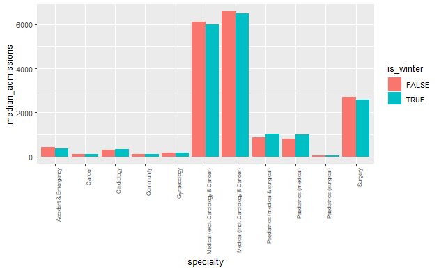

```r
hb_specialty %>%
  filter(admission_type == "Emergency",
         specialty != "All",
         hb_name == "All Scotland") %>%
  group_by(hb_name, specialty, is_winter) %>%
  summarise(median_admissions = median(number_admissions)) %>%
  ggplot() +
    geom_col(aes(x = specialty,
                  y = median_admissions,
                  fill = is_winter), position = "dodge") +
    theme(axis.text.x = element_text(angle = 90, hjust = 1, size =7))
```

```r
#grouped summary table by admission type
hb_specialty %>%
  filter(specialty == "All",
         hb_name == "All Scotland") %>%
  group_by(admission_type) %>%
  summarise(mean_admissions_covid = mean(number_admissions),
            mean_admissions_precovid = mean(average20182019),
            diff_mean_precovid_postcovid = mean_admissions_precovid - mean_admissions_covid)
```

| admission_type | mean_admissions_covid | mean_admissions_precovid | diff_mean_precovid_postcovid |
| --- | --- | --- | --- |
| All | 13095.223 | 15483.763 | 2388.540 |
| Emergency | 10692.920 | 12015.661 | 1322.741 |
| Planned | 2402.304 | 3468.103 | 1065.799 |

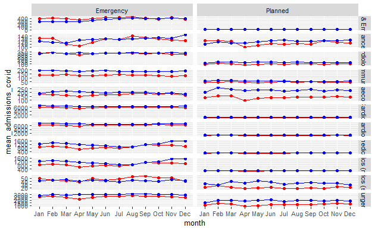

```r
#grouped summary table by specialty and admission type for all Scotland
hb_specialty %>%
  filter(specialty != "All",
         hb_name == "All Scotland",
         admission_type != "All") %>%
  group_by(month, specialty, admission_type) %>%
  summarise(mean_admissions_covid = mean(number_admissions),
            mean_admissions_precovid = mean(average20182019),
            diff_mean_precovid_postcovid = mean_admissions_precovid - mean_admissions_covid) %>%
  ggplot() +
  geom_point(aes(x = month,
            y = mean_admissions_covid),
            colour = "red") +
  geom_line(aes(x = month,
            y = mean_admissions_covid),
            colour = "red", group = 1) +
  geom_point(aes(x = month,
            y = mean_admissions_precovid),
            colour = "blue") +
  geom_line(aes(x = month,
            y = mean_admissions_precovid),
            colour = "blue", group = 1) +
  facet_grid(rows = vars(specialty),
             cols = vars(admission_type), scales = "free_y")
```

```r
#grouped summary table of mean admissions by hb, specialty and admission type for each month
hb_specialty %>%
  filter(specialty != "All",
         hb_name != "All Scotland",
         admission_type != "All") %>%
  group_by(hb_name, month, specialty, admission_type) %>%
  summarise(mean_admissions_covid = mean(number_admissions),
            mean_admissions_precovid = mean(average20182019),
            #get diff in means precovid vs during covid
            diff_mean_precovid_postcovid = mean_admissions_precovid - mean_admissions_covid) %>%
  #see only observations where the mean admissions increased during covid years
  filter(diff_mean_precovid_postcovid <= -1)
```

| hb_name | month | specialty | admission_type | mean_admissions_covid | mean_admissions_precovid | diff_mean_precovid_postcovid |
| --- | --- | --- | --- | --- | --- | --- |
| NHS Ayrshire and Arran | Jan | Cardiology | Planned | 7.000000 | 3.250000 | -3.750000 |
| NHS Ayrshire and Arran | Jan | Medical (excl. Cardiology & Cancer) | Planned | 6.500000 | 5.500000 | -1.000000 |
| NHS Ayrshire and Arran | Feb | Cardiology | Planned | 5.250000 | 3.625000 | -1.625000 |
| NHS Ayrshire and Arran | Feb | Paediatrics (medical & surgical) | Planned | 7.142857 | 4.285714 | -2.857143 |
| NHS Ayrshire and Arran | Feb | Paediatrics (medical) | Planned | 7.142857 | 4.285714 | -2.857143 |
| NHS Ayrshire and Arran | Mar | Cardiology | Planned | 6.600000 | 2.300000 | -4.300000 |
| NHS Ayrshire and Arran | Mar | Paediatrics (medical & surgical) | Planned | 7.166667 | 5.916667 | -1.250000 |
| NHS Ayrshire and Arran | Mar | Paediatrics (medical) | Planned | 7.166667 | 5.916667 | -1.250000 |
| NHS Ayrshire and Arran | Apr | Cardiology | Planned | 5.000000 | 1.500000 | -3.500000 |
| NHS Ayrshire and Arran | Apr | Paediatrics (medical & surgical) | Planned | 7.200000 | 4.500000 | -2.700000 |

[output cut: 580 more lines]

```r
hb_specialty %>%
  filter(specialty != "All",
         hb_name != "All Scotland") %>%
  group_by(hb_name, specialty, is_winter, admission_type) %>%
  summarise(mean_admissions_covid = mean(number_admissions),
            mean_admissions_precovid = mean(average20182019),
            #get diff in means precovid vs during covid
            diff_mean_precovid_postcovid = mean_admissions_precovid - mean_admissions_covid) %>%
  #see only observations where the mean admissions increased during covid years
  filter(diff_mean_precovid_postcovid <= -1)
```

| hb_name | specialty | is_winter | admission_type | mean_admissions_covid | mean_admissions_precovid | diff_mean_precovid_postcovid |
| --- | --- | --- | --- | --- | --- | --- |
| NHS Ayrshire and Arran | Cardiology | FALSE | Planned | 5.888889 | 2.611111 | -3.277778 |
| NHS Ayrshire and Arran | Cardiology | TRUE | Planned | 5.750000 | 3.250000 | -2.500000 |
| NHS Borders | Community | FALSE | Emergency | 5.333333 | 3.583333 | -1.750000 |
| NHS Borders | Medical (excl. Cardiology & Cancer) | FALSE | Planned | 6.307692 | 5.038462 | -1.269231 |
| NHS Borders | Medical (excl. Cardiology & Cancer) | TRUE | Planned | 6.875000 | 5.125000 | -1.750000 |
| NHS Borders | Medical (incl. Cardiology & Cancer) | TRUE | Planned | 6.545455 | 4.954545 | -1.590909 |
| NHS Dumfries and Galloway | Cardiology | FALSE | All | 6.419355 | 4.532258 | -1.887097 |
| NHS Dumfries and Galloway | Cardiology | FALSE | Planned | 6.684211 | 3.500000 | -3.184211 |
| NHS Dumfries and Galloway | Cardiology | TRUE | All | 6.266667 | 4.700000 | -1.566667 |
| NHS Dumfries and Galloway | Cardiology | TRUE | Planned | 5.700000 | 3.700000 | -2.000000 |

[output cut: 122 more lines]

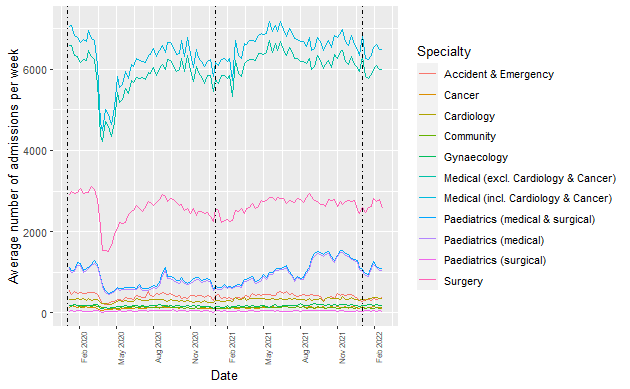

```r
#get line graph of average number of admissions over time for each specialty

hb_specialty %>%
  filter(admission_type == "Emergency",
         specialty != "All",
         hb_name == "All Scotland") %>%
  group_by(hb_name, week_ending, specialty) %>%
  summarise(mean_admissions = mean(number_admissions)) %>%
  ggplot() +
    geom_line(aes(x = week_ending,
                  y = mean_admissions,
                  colour = specialty)) +
  scale_x_date(date_breaks = "3 months", date_labels = "%b %Y") +
  theme(axis.text.x = element_text(angle = 90, hjust = 1, size =7)) +
   geom_vline(xintercept = as.numeric(as.Date("2020-01-01")), linetype=4)+
  geom_vline(xintercept = as.numeric(as.Date("2021-01-01")), linetype=4)+
  geom_vline(xintercept = as.numeric(as.Date("2022-01-01")), linetype=4)+
  labs(x = "Date",
       y = "Average number of admissions per week",
       colour = "Specialty")
```

```r
hb_specialty %>%
  filter(admission_type == "Emergency",
         specialty != "All",
         hb_name == "All Scotland") %>%
  group_by(hb_name, month, specialty) %>%
  summarise(mean_20182019_admissions = mean(average20182019)) %>%
  ggplot() +
  geom_point(aes(x = month,
                  y = mean_20182019_admissions,
                  colour = specialty)) +
    geom_line(aes(x = month,
                  y = mean_20182019_admissions,
                  colour = specialty), group = hb_specialty$specialty) +
  theme(axis.text.x = element_text(angle = 90, hjust = 1, size =7)) +
  labs(x = "Date",
       y = "Average number of admissions per week",
       colour = "Specialty")
```

[output not shown]

## HSCP Age/sex dataset

### Variables in dataset

```r
hscp_agesex <- read_csv("raw_data/covid_raw_data/hospital_admissions_hscp_agesex_20220302.csv") %>% clean_names()
```

```r
hscp_agesex %>% names()
```

Again, the HSCP code is not very helpful, it would be more useful to have the HSCP names and the HB they are tied to.

```r
#read in hscp names dataset
hscp_names <- read_csv("raw_data/covid_raw_data/hscp_names.csv") %>% clean_names()

#select the variables we need to add to the main table
hscp_names <- hscp_names %>%
  select(hscp, hscp_name, hb, hb_name)
```

```r
#join with hscp_names to get hscp and hb names

hscp_agesex <- hscp_agesex %>% left_join(hscp_names, by = "hscp")
```

### Check to see if hb and hscp datasets are interchangable

I noticed that HSCP and HB datasets contained the same variables and HSCP datasets contained the HB as well, so I thought that they might be interchangable since, in theory, when you group HSCP datasets by HB, the number of admissions should aggregate to the same numbers as the HB datasets since they are for the same time periods. This isn’t the case. The HSCP dataset recorded higher numbers of admissions when aggregated by HB and compared with the HB dataset.

```r
#summarise no of admissions by sex/age_group for each HB
hscp_agesex %>%
  group_by(hb, sex, age_group, admission_type) %>%
  summarise(total_admissions_by_sex = sum(number_admissions))
```

```r
#summarise no of admissions by sex/age_group for each HB
hb_agesex %>%
  group_by(hb, sex, age_group, admission_type) %>%
  summarise(total_admissions_by_sex = sum(number_admissions))
```

```r
#check number of admissions in each dataset for a random HB for the same week_ending date
hscp_agesex %>%
  select(week_ending, hb, age_group, sex, admission_type, number_admissions) %>%
  filter(hb == "S08000015",
         week_ending == "20200105") %>%
  group_by(week_ending, hb, sex, age_group, admission_type) %>%
  summarise(total_admissions = sum(number_admissions))

hb_agesex %>%
  select(week_ending, hb, age_group, sex, admission_type, number_admissions) %>%
  filter(hb == "S08000015",
         week_ending == "2020-01-05") %>%
  group_by(week_ending, hb, sex, age_group, admission_type) %>%
  summarise(total_admissions = sum(number_admissions))
```

[output not shown]

We should ask which dataset should be considered “correct” - I would suggest selecting the HSCP datasets b/c the numbers are higher, which makes me think that some admissions weren’t recorded in the HB dataset.

Can we get the proportion for no of admissions to population in each HB or HSCP? This would allow us to carry out statistical tests to see if any HBs or HSCPs have a higher proportion of admissions compared with Scotland overall